# Empirical Excercise 4.2

韩雨晴 罗真 庞博 娄纪凡

2017/3/28

# A Description of the Problem

On the text Web site http:://www.pearsonhighered.com/stock_watson/, you will find a data file TeachingRatings that contains data on course evaluations, course characteristics, and professor characteristics for 463 courses at the University of Texas at Austin. A detailed description is given in TeachingRatings_Description, also available on the Web site. One of the characteristics is an index of the profes- sor’s “beauty” as rated by a panel of six judges. In this exercise, you will investigate how course evaluations are related to the professor’s beauty.

# Answers to the Questions

course_eval

[output not shown]

1

Min. :2.100

Min. :-1.4504940

2

1st Qu.:3.600

1st Qu.:-0.6562689

3

Median :4.000

Median :-0.0680143

4

Mean :3.998

Mean : 0.0000001

5

3rd Qu.:4.400

3rd Qu.: 0.5456024

6

Max. :5.000

Max. : 1.9700230

## Question (a)

Our scatterplot of average course evaluations on the professor’s beauty is presented below.

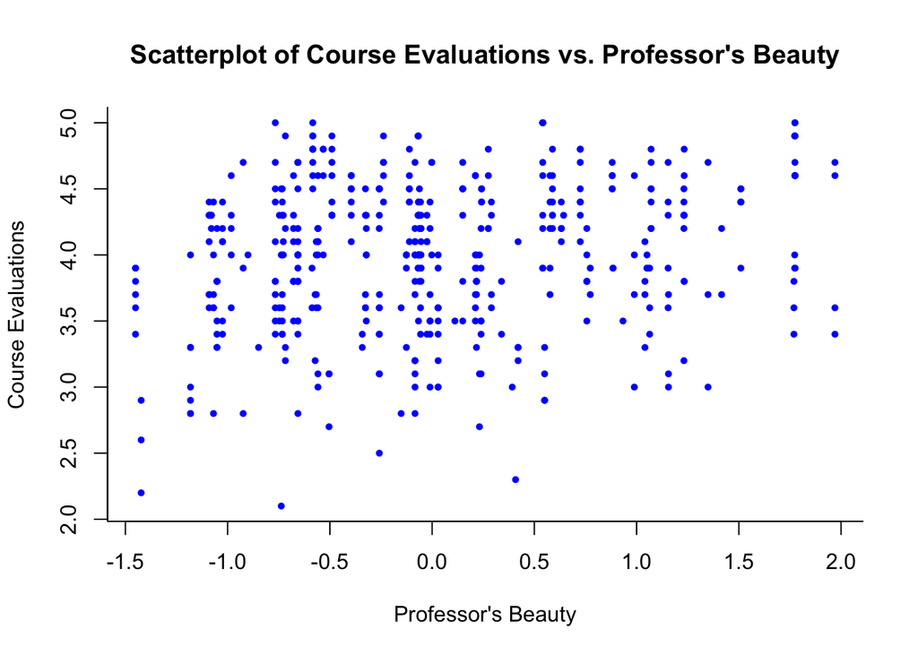

Since the plots are spreaded across the figure almost evenly,there doesn’t seem to be any obivious,strong relationship between the two.

## Question (b)

The regression line function we derived from the plot graph is presented below.

```
##
## Call:
## lm(formula = course_eval ~ beauty, data = df)
##
## Residuals:
##      Min       1Q   Median       3Q      Max
## -1.80015 -0.36304  0.07254  0.40207  1.10373
##
## Coefficients:
##             Estimate Std. Error t value Pr(>|t|)
## (Intercept)  3.99827    0.02535 157.727  < 2e-16 ***
## beauty       0.13300    0.03218   4.133 4.25e-05 ***
## ---
## Signif. codes:  0 '***' 0.001 '**' 0.01 '*' 0.05 '.' 0.1 ' ' 1
##
## Residual standard error: 0.5455 on 461 degrees of freedom
## Multiple R-squared:  0.03574,    Adjusted R-squared:  0.03364
## F-statistic: 17.08 on 1 and 461 DF,  p-value: 4.247e-05
```

$$\widehat{Course\hspace{2pt}Eval}=3.99827+0.133\times Beauty$$
The estimated intercept is 3.99827. The estimated slope is 0.133. Since the initial sample regression line function is presented as below,
$$\hat{Y_i}=\hat{\beta_0}+\hat{\beta_1}X_i$$
so we can derive that the sample average point is always on the sample regression line because
$$\bar{Y}=\hat{\beta_0}+\hat{\beta_1}\bar{X}$$
Since the $\bar{X}$(the sample mean of beauty) equals to zero, so the $\hat{\beta_0}$ (the estimated intercept) equals to $\bar{Y}$(the sample mean of course_eval).